# Poverty and Malnutrition Report (2020)

### Data sources

- Poverty in numbers: `gm_685pov_num.csv`
- Malnutrition (weight-for-age, percent of children under 5): `malnutrition_weight_for_age_percent_of_children_under_5.csv`

### Peek at the raw data

Sample of poverty dataset (wide format)

| country | 1800 | 1801 | 1802 | 1803 | 1804 | 1805 | 1806 | 1807 | 1808 | 1809 | 1810 | 1811 | 1812 | 1813 | 1814 | 1815 | 1816 | 1817 | 1818 | 1819 | 1820 | 1821 | 1822 | 1823 | 1824 | 1825 | 1826 | 1827 | 1828 | … |
| --- | --- | --- | --- | --- | --- | --- | --- | --- | --- | --- | --- | --- | --- | --- | --- | --- | --- | --- | --- | --- | --- | --- | --- | --- | --- | --- | --- | --- | --- | --- |
| Afghanistan | 3.25M | 3.25M | 3.25M | 3.25M | 3.25M | 3.25M | 3.25M | 3.25M | 3.25M | 3.25M | 3.25M | 3.25M | 3.25M | 3.25M | 3.25M | 3.25M | 3.25M | 3.25M | 3.25M | 3.25M | 3.26M | 3.26M | 3.28M | 3.29M | 3.31M | 3.32M | 3.34M | 3.35M | 3.37M | … |
| Angola | 1.56M | 1.56M | 1.56M | 1.56M | 1.56M | 1.56M | 1.56M | 1.56M | 1.56M | 1.56M | 1.56M | 1.56M | 1.56M | 1.56M | 1.56M | 1.56M | 1.56M | 1.56M | 1.56M | 1.56M | 1.57M | 1.59M | 1.6M | 1.63M | 1.65M | 1.68M | 1.7M | 1.73M | 1.75M | … |
| Albania | 397k | 399k | 401k | 402k | 404k | 406k | 408k | 409k | 411k | 413k | 415k | 417k | 419k | 421k | 422k | 424k | 426k | 428k | 430k | 432k | 434k | 436k | 437k | 439k | 441k | 443k | 445k | 447k | 449k | … |
| UAE | 35.3k | 35k | 35k | 35k | 35k | 35k | 35k | 35k | 35k | 34.7k | 34.7k | 34.7k | 34.7k | 34.7k | 34.7k | 34.7k | 34.4k | 34.4k | 34.4k | 34.4k | 34.4k | 34.4k | 34.4k | 34.1k | 34.1k | 34.2k | 34.2k | 34.2k | 34.2k | … |
| Argentina | 486k | 470k | 457k | 445k | 434k | 422k | 411k | 400k | 389k | 376k | 378k | 380k | 386k | 397k | 408k | 420k | 431k | 440k | 452k | 464k | 475k | 485k | 490k | 499k | 508k | 516k | 521k | 530k | 539k | … |

Sample of malnutrition dataset (wide format)

| country | 1983 | 1984 | 1985 | 1986 | 1987 | 1988 | 1989 | 1990 | 1991 | 1992 | 1993 | 1994 | 1995 | 1996 | 1997 | 1998 | 1999 | 2000 | 2001 | 2002 | 2003 | 2004 | 2005 | 2006 | 2007 | 2008 | 2009 | 2010 | 2011 | … |
| --- | --- | --- | --- | --- | --- | --- | --- | --- | --- | --- | --- | --- | --- | --- | --- | --- | --- | --- | --- | --- | --- | --- | --- | --- | --- | --- | --- | --- | --- | --- |
| Afghanistan | NA | NA | NA | NA | NA | NA | NA | NA | NA | NA | NA | NA | NA | NA | 44.9 | NA | NA | NA | NA | NA | NA | 31.7 | NA | NA | NA | NA | NA | NA | NA | … |
| Angola | NA | NA | NA | NA | NA | NA | NA | NA | NA | NA | NA | NA | NA | 36.2 | NA | NA | NA | NA | NA | NA | NA | NA | NA | NA | 15.1 | NA | NA | NA | NA | … |
| Albania | NA | NA | NA | NA | NA | NA | NA | NA | NA | NA | NA | NA | NA | NA | NA | NA | NA | NA | NA | NA | NA | NA | 6.6 | NA | NA | NA | 6.3 | NA | NA | … |
| Argentina | NA | NA | NA | NA | NA | NA | NA | NA | NA | NA | NA | 1.7 | NA | 4.7 | NA | NA | NA | NA | NA | NA | NA | NA | 2.5 | NA | NA | NA | NA | NA | NA | … |
| Armenia | NA | NA | NA | NA | NA | NA | NA | NA | NA | NA | NA | NA | NA | NA | NA | 2.7 | NA | 2.6 | NA | NA | NA | NA | 4.2 | NA | NA | NA | NA | 5.3 | NA | … |

### Prepare 2020 indicators and harmonize country keys

### Indicator 1: Poverty in numbers (2020)

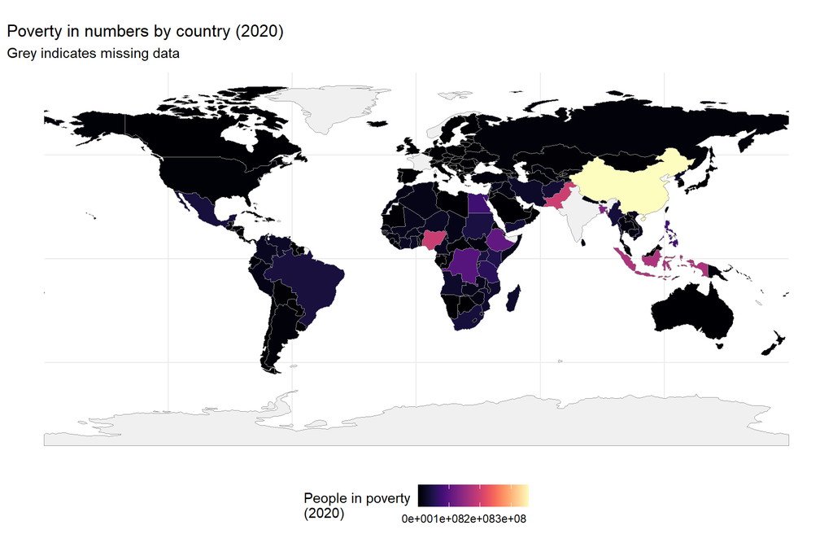

### Indicator 2: Malnutrition, weight-for-age under 5 (%, 2020)

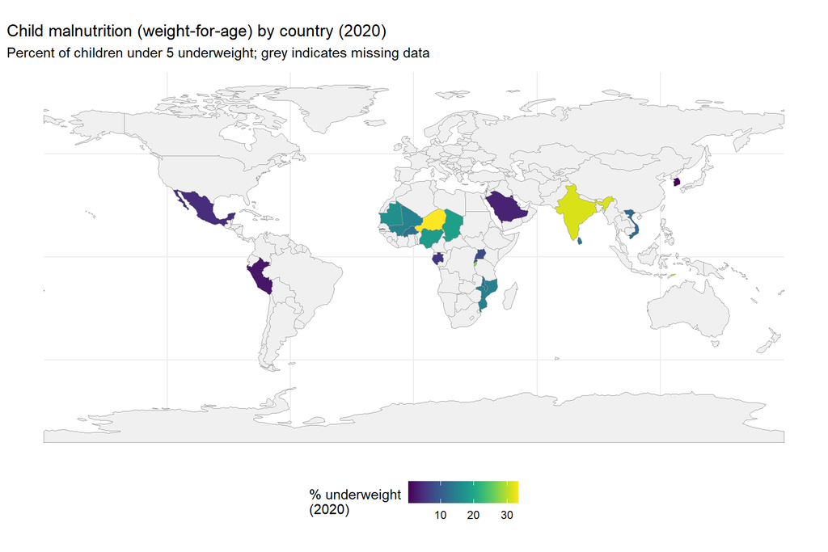

### Relationship between poverty and malnutrition (2020)

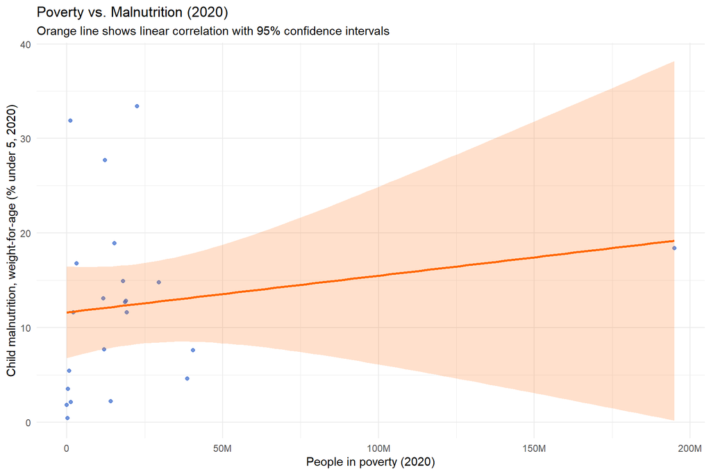

### Brief interpretation

Key figures (computed during this report):

- Countries with both measures available: 22
- Median malnutrition rate (%): 12.1
- Median poverty count (people): 13 150 000

### My reflection

- What was easy? -> It was easy to explore the datasets and using my R skills to instruct precisely the AI agent on what to change in the Rmd.
- What was difficult? -> It was difficult to follow (and comprehend) the coding lines, as the AI agent does not comment on the code lines (may I have to prompt him to do so?!)
- What was surprising? -> It was surprising how the AI agent came up with different code when exploring various combinations of datasets (undetermined genAI !!!)
- What did you learn? -> A lot! Especially that I lost my reservedness towards collaborating with AI when analysing data!